# Data Visualization with ggplot2 (Part 2)

Coordinates and Facets

Seun Odeyemi

2019-04-08

## Load Libraries

```r
library(readr)
library(dplyr)
library(ggplot2)
library(tidyr)
library(skimr)
library(knitr)
library(kableExtra)
library(RColorBrewer)
```

## Zooming In

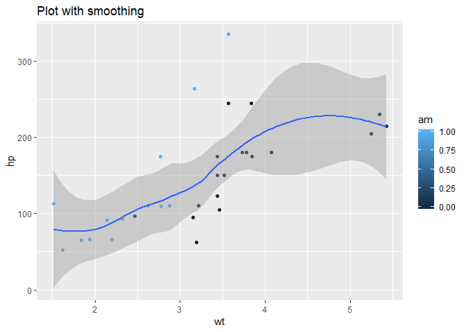

```r
# Basic ggplot() command, coded for you
p1 <- ggplot(mtcars, aes(x = wt, y = hp, col = am)) +
  geom_point() +
  geom_smooth() +
  ggtitle("Plot with smoothing")
p1
```

[output not shown]

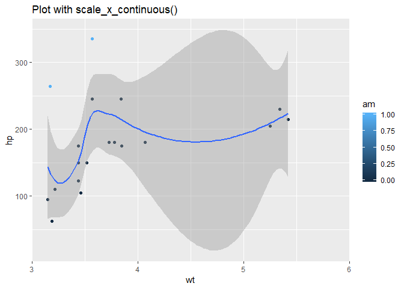

```r
# Add scale_x_continuous()
p2 <- p1 + scale_x_continuous(limits = c(3, 6), expand = c(0, 0)) +
  ggtitle("Plot with scale_x_continuous()")
p2
```

```
#> Warning: Removed 12 rows containing non-finite values (stat_smooth).
```

```
#> Warning: Removed 12 rows containing missing values (geom_point).
```

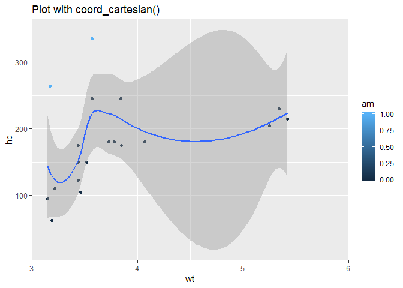

```r
# Add coord_cartesian(): the proper way to zoom in
p3 <- p2 + coord_cartesian(xlim = c(3, 6)) +
  ggtitle("Plot with coord_cartesian()")
p3
```

```r
# multiplot(p1, p2, p3, cols = 2)
```

Good job! Always pay attention to the ggplot2 warning messages in case data has been removed from your plot!

## Aspect Ratio

We can set the aspect ratio of a plot with `coord_fixed()` or `coord_equal()`. Both use ratio = 1 as a default. A *1:1 aspect ratio is most appropriate when two continuous variables are on the same scale, as with the iris dataset*.

All variables are measured in centimeters, so it only makes sense that one unit on the plot should be the same physical distance on each axis. This gives a more truthful depiction of the relationship between the two variables since the aspect ratio can change the angle of our smoothing line. This would give an erroneous impression of the data.

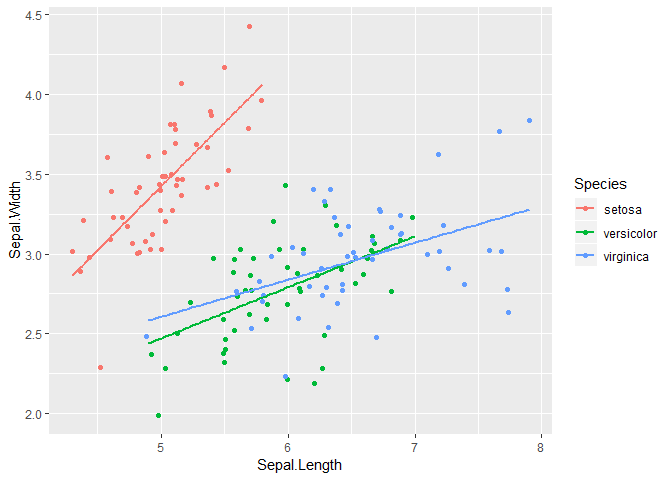

```r
# Complete basic scatter plot function
base.plot <- ggplot(iris, aes(x = Sepal.Length, y = Sepal.Width, col = Species)) +
               geom_jitter() +
               geom_smooth(method = "lm", se = FALSE)

# Plot base.plot: default aspect ratio
base.plot
```

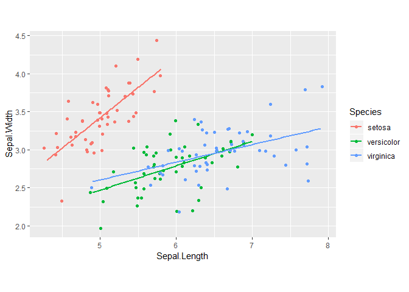

```r
# Fix aspect ratio (1:1) of base.plot
base.plot2 <- base.plot + coord_equal()
base.plot2
```

Good job! As a rule of thumb you’ll want to use a 1:1 aspect ratio when your axes show the same scales, but there are always exceptions.

## Pie Charts

The `coord_polar()` function converts a planar x-y Cartesian plot to polar coordinates. This can be useful if you are producing pie charts.

We can imagine two forms for pie charts - the typical filled circle, or a colored ring.

As an example, consider the stacked bar chart shown in the viewer. Imagine that we just take the y axis on the left and bend it until it loops back on itself, while expanding the right side as we go along. We’d end up with a pie chart - it’s simply a bar chart transformed onto a polar coordinate system.

Typical pie charts omit all of the non-data ink, which we’ll learn about in the next chapter. Pie charts are not really better than stacked bar charts, but we’ll come back to this point in the fourth chapter on best practices.

The mtcars data frame is available, with cyl converted to a factor for you.

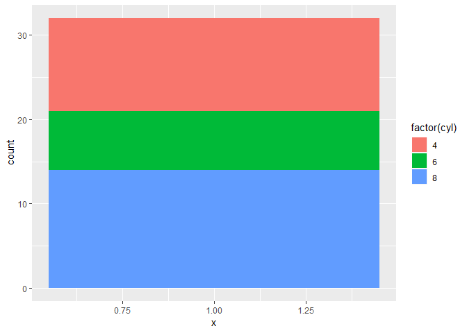

```r
# Create a stacked bar plot: wide.bar
wide.bar <- ggplot(mtcars, aes(x = 1, fill = factor(cyl))) +
              geom_bar()
wide.bar
```

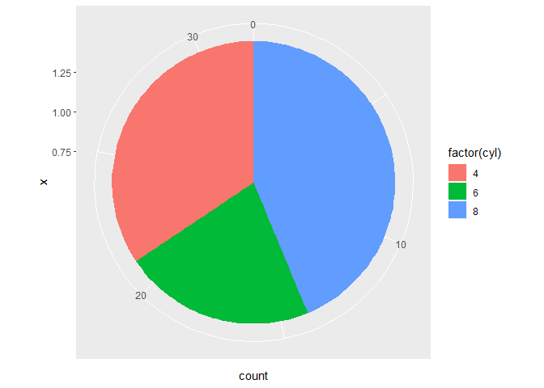

```r
# Convert wide.bar to pie chart
w2 <- wide.bar +
  coord_polar(theta = "y")
w2
```

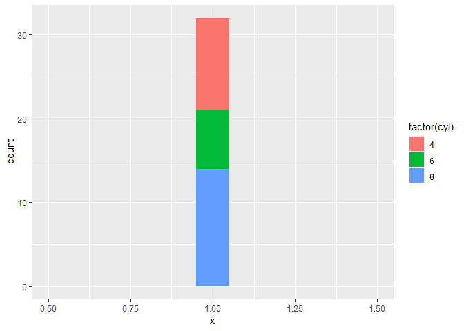

```r
# Create stacked bar plot: thin.bar
thin.bar <- ggplot(mtcars, aes(x = 1, fill = factor(cyl))) +
              geom_bar(width =  0.1) +
              scale_x_continuous(limits = c(0.5,1.5))
thin.bar
```

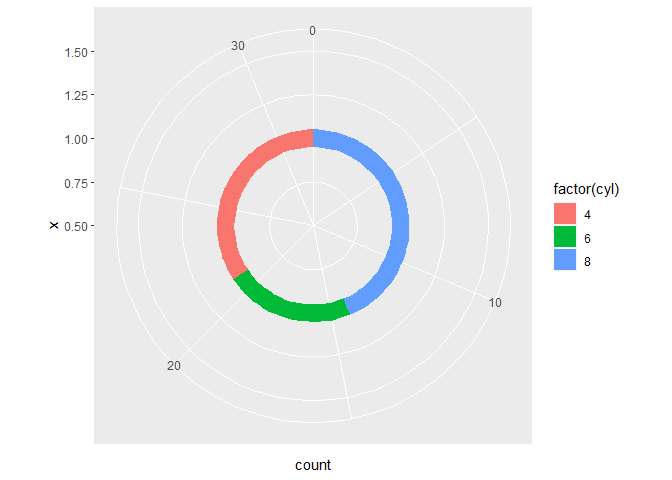

```r
# Convert thin.bar to "ring" type pie chart
t2 <- thin.bar +
  coord_polar(theta = "y")
t2
```

```r
# multiplot(wide.bar, w2, thin.bar, t2, cols = 2)
```

Good job! This function is particularly useful if you are dealing with a cycle, like yearly data, that you would like to see represented as such.

## Facets: The Basics

The most straightforward way of using facets is **`facet_grid()`**. Here we just need to specify the categorical variable to use on rows and columns using standard R formula notation (rows ~ columns).

Notice that we can also take advantage of ordinal variables by positioning them in the correct order as columns or rows, as is the case with the number of cylinders. Get some hands-on practice in this exercise; `ggplot2` is already loaded for you and `mtcars` is available. The variables `cyl` and `am` are factors. However, this is not necessary for facets; ggplot2 will coerce variables to factors in this case.

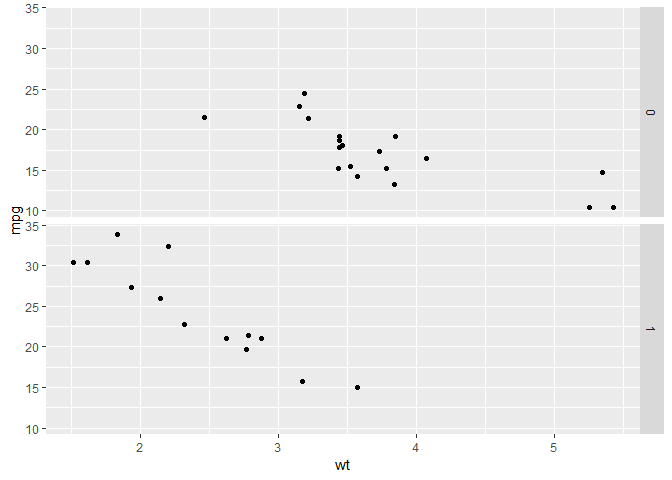

```r
# Basic scatter plot
p <- ggplot(mtcars, aes(x = wt, y = mpg)) +
  geom_point()

# 1 - Separate rows according to transmission type, am
p +
  facet_grid(am ~ .)
```

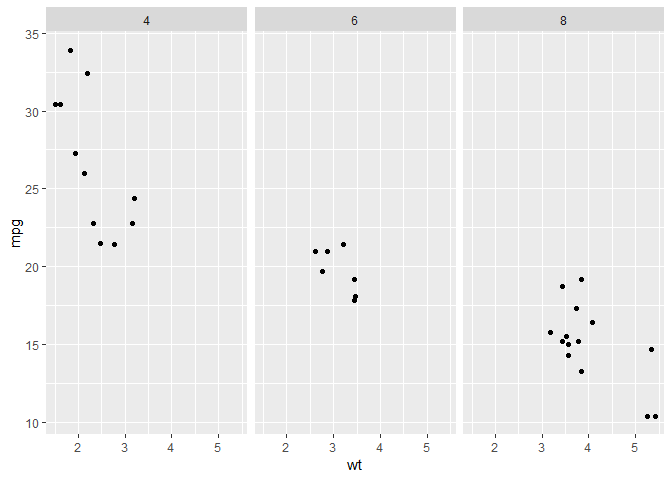

```r
# 2 - Separate columns according to cylinders, cyl
p +
  facet_grid(. ~ cyl)
```

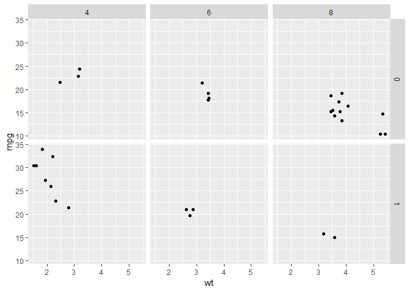

```r
# 3 - Separate by both columns and rows
p +
  facet_grid(am ~ cyl)
```

### Facets: Many Variables

Facets are another way of presenting categorical variables. Recall that we saw all the ways of combining variables, both categorical and continuous, in the aesthetics chapter. Sometimes it’s possible to overdo it. Here we’ll present a plot with 6 variables and see if we can add even more.

Let’s begin by using a trick to map two variables onto two color scales - hue and lightness. We combine `cyl` and `am` into a single variable `cyl_am`. To accommodate this we also make a new color palette with alternating red and blue of increasing darkness. This is saved as `myCol`. If you are not familiar with these steps, execute the code piece-by-piece.

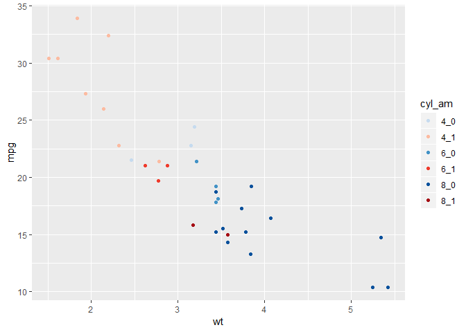

```r
# Code to create the cyl_am col and myCol vector
mtcars$cyl_am <- paste(mtcars$cyl, mtcars$am, sep = "_")
myCol <- rbind(brewer.pal(9, "Blues")[c(3,6,8)],
               brewer.pal(9, "Reds")[c(3,6,8)])

# Map cyl_am onto col
ggplot(mtcars, aes(x = wt, y = mpg, col = cyl_am)) +
  geom_point() +
  # Add a manual colour scale
  scale_color_manual(values = myCol)
```

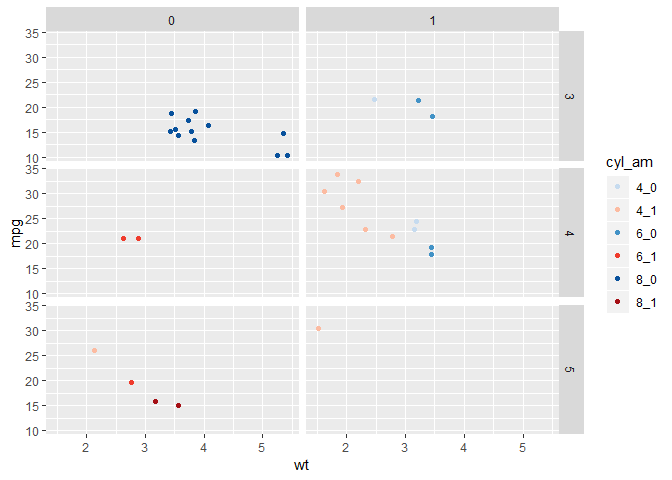

```r
# Grid facet on gear vs. vs
ggplot(mtcars, aes(x = wt, y = mpg, col = cyl_am)) +
  geom_point() +
  # Add a manual colour scale
  scale_color_manual(values = myCol) +
  facet_grid(gear ~ vs)
```

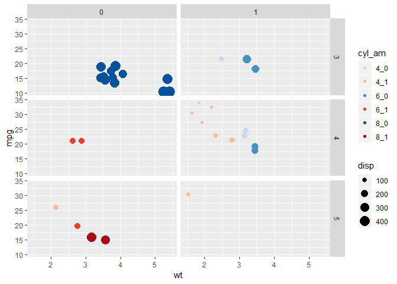

```r
# Also map disp to size
ggplot(mtcars, aes(x = wt, y = mpg, col = cyl_am, size = disp)) +
  geom_point() +
  # Add a manual colour scale
  scale_color_manual(values = myCol) +
  facet_grid(gear ~ vs)
```

## Works Cited

Tufte, Edward. 2001. *The Visual Display of Quantitative Information*. Cheshire, Connecticut: Graphics Press. https://www.amazon.com/Visual-Display-Quantitative-Information/dp/0961392142/ref=sr_1_1?crid=1HZWDJS6LQFV7&keywords=the+visual+display+of+quantitative+information&qid=1552938824&s=gateway&sprefix=the+visual%2Caps%2C130&sr=8-1.